# Part I - ( Melbourne Housing Dataset Exploration)

## Introduction

> The entire dataset is comprised of 21 variables with 8 variables as characters or strings. Before moving onto the effect on the target variable (Price) by those 8 variables. Every row in the dataset denotes information about property (house, townhouse etc) , price it is sold for, seller information and more characteristics such as number of bedrooms, location (latitude, longitude etc)

> **Dataset Dictionary**

Suburb: Suburb

Address: Address

Rooms: Number of rooms

Price: Price in Australian dollars

Method: S - property sold; SP - property sold prior; PI - property passed in; PN - sold prior not disclosed; SN - sold not disclosed; NB - no bid; VB - vendor bid; W - withdrawn prior to auction; SA - sold after auction; SS - sold after auction price not disclosed. N/A - price or highest bid not available.

Type: h - house,cottage,villa, semi,terrace; u - unit, duplex; t - townhouse;

SellerG: Real Estate Agent

Date: Date sold

Distance: Distance from CBD in Kilometres

Regionname: General Region (West, North West, North, North east …etc)

Propertycount: Number of properties that exist in the suburb.

Bedroom2 : Scraped # of Bedrooms (from different source)

Bathroom: Number of Bathrooms

Car: Number of carspots

Landsize: Land Size in Metres

BuildingArea: Building Size in Metres

YearBuilt: Year the house was built

CouncilArea: Governing council for the area

Lattitude: Location on earth

Longtitude: Location on earth

## Preliminary Wrangling

```python
# import all packages and set plots to be embedded inline
import numpy as np
import pandas as pd
import matplotlib.pyplot as plt
import seaborn as sb

%matplotlib inline
```

```python
import warnings
warnings.simplefilter("ignore")
```

> Loading dataset

```python
melb_df = pd.read_csv('melb_data.csv')
```

```python
# replacing multiple values with multiple new values for Type colulm
melb_df['Type'] = melb_df['Type'].replace(['h','u','t'],['House','Unit','TownHouse'])
```

```python
# printing 5 rows
melb_df.head()
```

|  | Suburb | Address | Rooms | Type | Price | Method | SellerG | Date | Distance | Postcode | ... | Bathroom | Car | Landsize | BuildingArea | YearBuilt | CouncilArea | Lattitude | Longtitude | Regionname | Propertycount |
| --- | --- | --- | --- | --- | --- | --- | --- | --- | --- | --- | --- | --- | --- | --- | --- | --- | --- | --- | --- | --- | --- |
| 0 | Abbotsford | 85 Turner St | 2 | House | 1480000.0 | S | Biggin | 3/12/2016 | 2.5 | 3067.0 | ... | 1.0 | 1.0 | 202.0 | NaN | NaN | Yarra | -37.7996 | 144.9984 | Northern Metropolitan | 4019.0 |
| 1 | Abbotsford | 25 Bloomburg St | 2 | House | 1035000.0 | S | Biggin | 4/02/2016 | 2.5 | 3067.0 | ... | 1.0 | 0.0 | 156.0 | 79.0 | 1900.0 | Yarra | -37.8079 | 144.9934 | Northern Metropolitan | 4019.0 |
| 2 | Abbotsford | 5 Charles St | 3 | House | 1465000.0 | SP | Biggin | 4/03/2017 | 2.5 | 3067.0 | ... | 2.0 | 0.0 | 134.0 | 150.0 | 1900.0 | Yarra | -37.8093 | 144.9944 | Northern Metropolitan | 4019.0 |
| 3 | Abbotsford | 40 Federation La | 3 | House | 850000.0 | PI | Biggin | 4/03/2017 | 2.5 | 3067.0 | ... | 2.0 | 1.0 | 94.0 | NaN | NaN | Yarra | -37.7969 | 144.9969 | Northern Metropolitan | 4019.0 |
| 4 | Abbotsford | 55a Park St | 4 | House | 1600000.0 | VB | Nelson | 4/06/2016 | 2.5 | 3067.0 | ... | 1.0 | 2.0 | 120.0 | 142.0 | 2014.0 | Yarra | -37.8072 | 144.9941 | Northern Metropolitan | 4019.0 |

5 rows × 21 columns

```python
# This method produces total No. of rows
melb_df.shape
```

```
(13580, 21)
```

```python
#The  function is used to print a concise summary of a DataFrame
melb_df.info()
```

```
<class 'pandas.core.frame.DataFrame'>
RangeIndex: 13580 entries, 0 to 13579
Data columns (total 21 columns):
 #   Column         Non-Null Count  Dtype
---  ------         --------------  -----
 0   Suburb         13580 non-null  object
 1   Address        13580 non-null  object
 2   Rooms          13580 non-null  int64
 3   Type           13580 non-null  object
 4   Price          13580 non-null  float64
 5   Method         13580 non-null  object
 6   SellerG        13580 non-null  object
 7   Date           13580 non-null  object
 8   Distance       13580 non-null  float64
 9   Postcode       13580 non-null  float64
 10  Bedroom2       13580 non-null  float64
 11  Bathroom       13580 non-null  float64
 12  Car            13518 non-null  float64
 13  Landsize       13580 non-null  float64
 14  BuildingArea   7130 non-null   float64
 15  YearBuilt      8205 non-null   float64
 16  CouncilArea    12211 non-null  object
 17  Lattitude      13580 non-null  float64
 18  Longtitude     13580 non-null  float64
 19  Regionname     13580 non-null  object
 20  Propertycount  13580 non-null  float64
dtypes: float64(12), int64(1), object(8)
memory usage: 2.2+ MB
```

```python
#The describe() method returns description of the data in the DataFrame.
melb_df.describe()
```

|  | Rooms | Price | Distance | Postcode | Bedroom2 | Bathroom | Car | Landsize | BuildingArea | YearBuilt | Lattitude | Longtitude | Propertycount |
| --- | --- | --- | --- | --- | --- | --- | --- | --- | --- | --- | --- | --- | --- |
| count | 13580.000000 | 1.358000e+04 | 13580.000000 | 13580.000000 | 13580.000000 | 13580.000000 | 13518.000000 | 13580.000000 | 7130.000000 | 8205.000000 | 13580.000000 | 13580.000000 | 13580.000000 |
| mean | 2.937997 | 1.075684e+06 | 10.137776 | 3105.301915 | 2.914728 | 1.534242 | 1.610075 | 558.416127 | 151.967650 | 1964.684217 | -37.809203 | 144.995216 | 7454.417378 |
| std | 0.955748 | 6.393107e+05 | 5.868725 | 90.676964 | 0.965921 | 0.691712 | 0.962634 | 3990.669241 | 541.014538 | 37.273762 | 0.079260 | 0.103916 | 4378.581772 |
| min | 1.000000 | 8.500000e+04 | 0.000000 | 3000.000000 | 0.000000 | 0.000000 | 0.000000 | 0.000000 | 0.000000 | 1196.000000 | -38.182550 | 144.431810 | 249.000000 |
| 25% | 2.000000 | 6.500000e+05 | 6.100000 | 3044.000000 | 2.000000 | 1.000000 | 1.000000 | 177.000000 | 93.000000 | 1940.000000 | -37.856822 | 144.929600 | 4380.000000 |
| 50% | 3.000000 | 9.030000e+05 | 9.200000 | 3084.000000 | 3.000000 | 1.000000 | 2.000000 | 440.000000 | 126.000000 | 1970.000000 | -37.802355 | 145.000100 | 6555.000000 |
| 75% | 3.000000 | 1.330000e+06 | 13.000000 | 3148.000000 | 3.000000 | 2.000000 | 2.000000 | 651.000000 | 174.000000 | 1999.000000 | -37.756400 | 145.058305 | 10331.000000 |
| max | 10.000000 | 9.000000e+06 | 48.100000 | 3977.000000 | 20.000000 | 8.000000 | 10.000000 | 433014.000000 | 44515.000000 | 2018.000000 | -37.408530 | 145.526350 | 21650.000000 |

### What is the structure of your dataset?

> My dataset has 13580 rows and 21 columns having both qualitative and quantitative data

### What is/are the main feature(s) of interest in your dataset?

> Price

### What features in the dataset do you think will help support your investigation into your feature(s) of interest?

> Rooms Type Distance Regionname Landsize Bathrooms Car

## Univariate Exploration

### What is the mode of distribution of data?

```python
#Return the base 10 logarithm of the input array, element-wise
np.log10(melb_df['Price'].describe())
```

```
count    4.132900
mean     6.031685
std      5.805712
min      4.929419
25%      5.812913
50%      5.955688
75%      6.123852
max      6.954243
Name: Price, dtype: float64
```

[figure not shown]

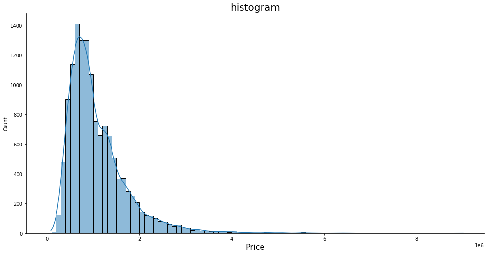

```python
plt.figure(figsize=[20,5])


#setting the bins
plt.subplot(1,2,1)
bins=10**np.arange(4,7+0.1,0.1)
#plotting
plt.hist(data=melb_df,x='Price',bins=bins);
plt.xscale('log')
plt.xlabel('x_axis limits are changed and scaled to logtype')


def hist_destribution(data, x, range, titles):
    bins = np.arange(0, range.max()+100000, 100000)      # Creating the bins for the histogram
    color=sb.color_palette()[0]       #Adding color
    sb.displot(data, x=x, height=7.0, aspect=2.0, bins=bins, kde = True, color=color);  #Ploting the displot
    plt.title(titles, fontdict={'fontsize': 20, 'fontweight': 'medium'})     # adding a tittle
    plt.xlabel(x.replace('_' ,' ').title(), fontdict={'fontsize': 16, 'fontweight': 'medium'}) # X label
plt.subplot(1,2,2)
hist_destribution(melb_df, 'Price', melb_df.Price, 'histogram')
```

### What is the distribution of houses in respect to Rooms?

```python
#The value_counts() function is used to get a Series containing counts of unique values
melb_df.Rooms.value_counts()
```

```
3     5881
2     3648
4     2688
1      681
5      596
6       67
7       10
8        8
10       1
Name: Rooms, dtype: int64
```

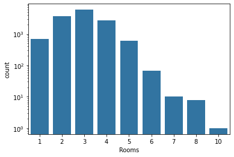

```python
#plotting a barchart through countplot fucn in seaborn
base_color=sb.color_palette()[0]
sb.countplot(data=melb_df,x='Rooms',color=base_color);
#transforming the y axis to log
plt.yscale('log')
```

### Observations

> Houses with 3 rooms seems to be the most built and 10 room houses are the least built in the region

### What is the general overview of Type column?

```python
#number of unique values
melb_df.Type.value_counts()
```

```
House        9449
Unit         3017
TownHouse    1114
Name: Type, dtype: int64
```

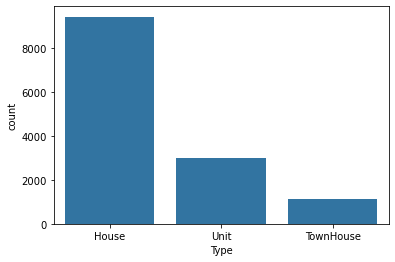

```python
base_color=sb.color_palette()[0]
sb.countplot(data=melb_df,x='Type',color=base_color);
```

### Observations

> House(cottage,villa,terrance) takes the largest portion which is more of residential and townhouse is the least where one common wall is shared differing from a home where the house sits on its own parcel,unit(duplex),duplex units are more affordable to rent than single family homes, a more desirable neighborhood might be in your price range if you’re renting a duplex and Townhouses are a style of multi-floor home and their ownership is more of corporation, investors, or a group,although Townhouse has restrictions,noise pollution and muiltifloor aspect isn't sustainable to most people

### Distance distribution of the houses from the cbd

```python
#total number of unique values
melb_df.Distance.value_counts()
```

```
11.2    739
9.2     367
13.9    324
7.8     306
4.6     263
       ...
37.5      1
29.3      1
47.4      1
39.8      1
48.1      1
Name: Distance, Length: 202, dtype: int64
```

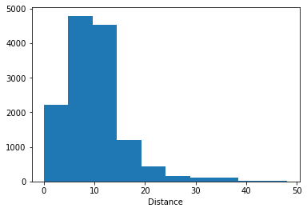

```python
#plotting hist thro matplotlib
plt.hist(data=melb_df,x='Distance');
plt.xlabel('Distance')
```

### Observations

> Most buildings are located between 0 and 15 kilomettres away from the cbd and the highest number found at around 11 kilometres thus distance is factor in realEstate

### What is the distribution of carspots?

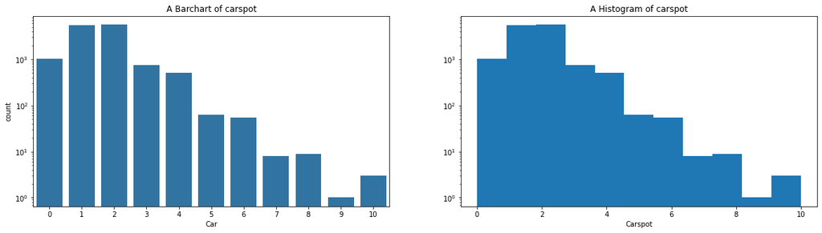

```python
#plotting hist thro matplotlib
plt.figure(figsize=[20,5])

plt.subplot(1,2,1)
base_color=sb.color_palette()[0]
sb.countplot(data=melb_df,x='Car',color=base_color);
plt.yscale('log')
plt.title('A Barchart of carspot');
# histogram with log transformation
plt.subplot(1,2,2)
plt.hist(data=melb_df,x='Car',bins=11);
plt.xlabel('Carspot')
plt.yscale('log')
plt.title('A Histogram of carspot');
```

### Observation

> My column car has discrete values and barcharts should be appropriate to show the trend but I also included a histogram to know the skewness of the data. Most Residentials have 1 or 2 carspot and the highest carpot record is 10. The data is right skewed with a largest frequency at 1-2 carpots

### How is the ditribution of buildings around the Regions?

```python
melb_df.Regionname.value_counts()
```

```
Southern Metropolitan         4695
Northern Metropolitan         3890
Western Metropolitan          2948
Eastern Metropolitan          1471
South-Eastern Metropolitan     450
Eastern Victoria                53
Northern Victoria               41
Western Victoria                32
Name: Regionname, dtype: int64
```

```python
Region_count=melb_df['Regionname'].value_counts()
```

```python
# this arranges the regions in order of index
Region_order=Region_count.index
```

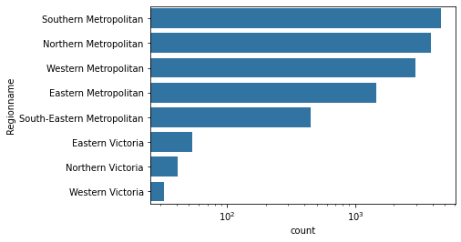

```python
base_color=sb.color_palette()[0]
sb.countplot(data=melb_df,y='Regionname',color=base_color,order=Region_order);
plt.xscale('log')#scaling my data to have a clear visual on all the regions
```

### Observations

> Southern Metropolitan has the highest number in terms of real estate while Western Victoria has the least number

### Is landsize factor in housing?

```python
np.log10(melb_df['Landsize'].describe())
```

```
count    4.132900
mean     2.746958
std      3.601046
min          -inf
25%      2.247973
50%      2.643453
75%      2.813581
max      5.636502
Name: Landsize, dtype: float64
```

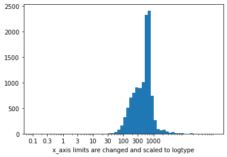

```python
bins=10**np.arange(-1,5+0.1,0.1)
ticks=[0.1,0.3,1,3,10,30,100,300,1000]
labels=['{}'.format(v) for v in ticks]
plt.hist(data=melb_df,x='Landsize',bins=bins);
plt.xscale('log');
plt.xticks(ticks,labels);
plt.xlabel('x_axis limits are changed and scaled to logtype')
```

### What is the distribution of bathrooms among the buldings?

```python
melb_df.Bathroom.value_counts()
```

```
1.0    7512
2.0    4974
3.0     917
4.0     106
0.0      34
5.0      28
6.0       5
7.0       2
8.0       2
Name: Bathroom, dtype: int64
```

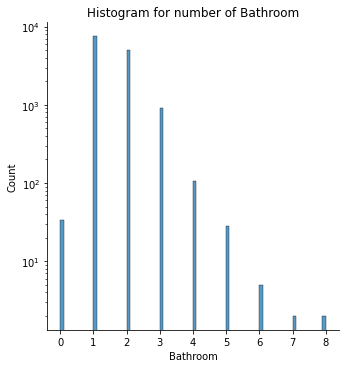

```python
#setting bins sizes
bins_edges=np.arange(0,melb_df['Bathroom'].max()+0.1,0.1)
sb.displot(melb_df['Bathroom'],bins= bins_edges,kde=False);
plt.yscale('log')# scaling yaxis
plt.title("Histogram for number of Bathroom");
```

### Obsevation

> Number of Bathrooms is quite interesting with buldings with one bathroom being dorminant while buldings with 7 and 8 bathrooms being the least

### Discuss the distribution(s) of your variable(s) of interest. Were there any unusual points? Did you need to perform any transformations?

> With the size of the columns, values counts of the variables seems quite large,thus inorder to get a clear picture of my data I have scaled the relevants axis during plotting. I transformed Price and landizes through numpy.log10 to get a clear plot for hist plot

### Of the features you investigated, were there any unusual distributions? Did you perform any operations on the data to tidy, adjust, or change the form of the data? If so, why did you do this?

> On the type column I renamed **h,t,u** types to more descriptives names inorder to have a clear naming in barcharts,prices had a distribution that had no smaller values thus the histogram was far right after transforming the price data

## Bivariate Exploration

### What is the relationship between price and Number of Bathrooms?

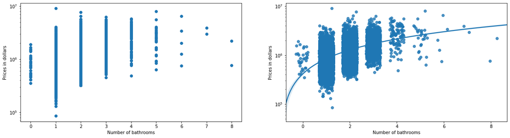

```python
# setting the figure size
plt.figure(figsize=[20,5])

plt.subplot(1,2,1)
plt.scatter(data=melb_df,x='Bathroom',y='Price');
plt.xlabel('Number of bathrooms')
plt.ylabel('Prices in dollars')
plt.yscale('log')

plt.subplot(1,2,2)
sb.regplot(data=melb_df,x='Bathroom',y='Price',x_jitter=0.3,truncate=False)
plt.xlabel('Number of bathrooms')
plt.ylabel('Prices in dollars')
plt.yscale('log')
```

### What is the relationship between regions and price?

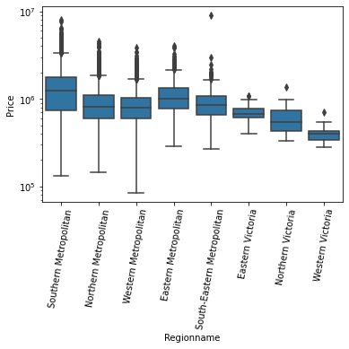

```python
# boxplot
sb.boxplot(data=melb_df, x='Regionname', y='Price', color=base_color,order=Region_order)
plt.xticks(rotation=80);
plt.yscale('log')#scaling y axisbbb
```

### Observation

> Prices vary among diferent regions with southern having the highest median and western victoria trailing

### What is the relationship between price and Type?

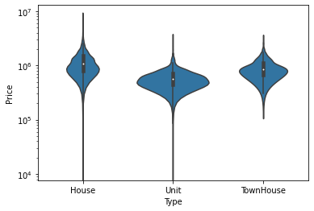

```python
base_color=sb.color_palette()[0]
sb.violinplot(data=melb_df,x='Type',y='Price',color=base_color);
plt.yscale('log')
```

### Observations

> I have used violin plots to depicts the relationships which seems quite consistent but unit type has a wider section representing a higher probability that investors will take on a given value while house has a lower probality but have a relative higher median which I suppose comes from variance in prices where their prices are higher, the shape of the distribution is quite skinny on each end and wide in the middle for Types indicating the prices of differents types of buildings are highly concentrated around the median

### What is the relationship between distance and Type of residentials?

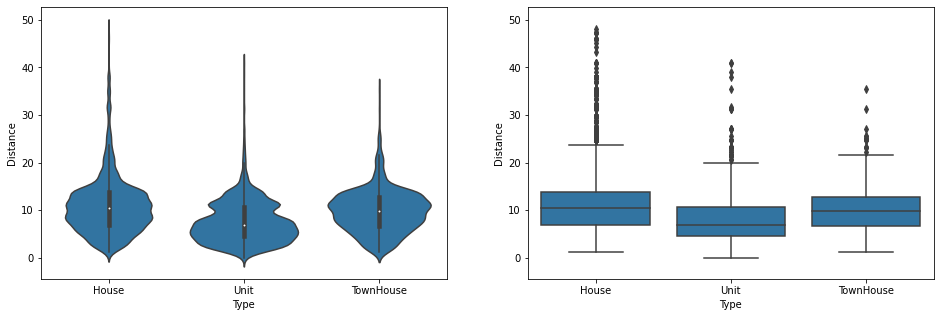

```python
plt.figure(figsize = [16, 5])
base_color = sb.color_palette()[0]

# LEFT plot: violin plot
plt.subplot(1, 2, 1)
# returning the axes object
ax1 = sb.violinplot(data=melb_df, x='Type', y='Distance', color=base_color)
plt.xticks(rotation=0);

# RIGHT plot: box plot
plt.subplot(1, 2, 2)
sb.boxplot(data=melb_df, x='Type', y='Distance', color=base_color)
plt.xticks(rotation=0);
plt.ylim(ax1.get_ylim());
```

### What is the relationships between Types and Number of Bathrroms?

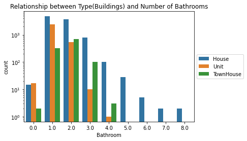

```python
sb.countplot(data = melb_df, x = 'Bathroom', hue = 'Type');
plt.yscale('log')
plt.legend(loc = 6, bbox_to_anchor = (1.0, 0.5));# legend on the rightside of the figure
plt.title('Relationship between Type(Buildings) and Number of Bathrooms');
```

### Observations

> I have used clustered bar charts to depicts the visuals and the insights drawned is that number of Bathrooms greatly depend on Types of structures. From the above visual House(cottage,villa,mansion) has the more bathrooms than the rest, this can be attributed to individual ownership and the rationale of No. of bathrooms depends on the owner and number of people living in that house,Unit(duplex) has an advantage on renting havinf a relative rent rate and limited number of bathrooms with Townhouse

### What is the relationship between landsize and Type?

```python
sb.reset_orig()
```

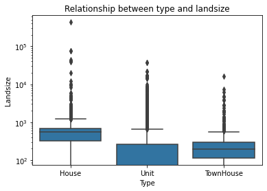

```python
sb.boxplot(data=melb_df, x='Type', y='Landsize', color=base_color)
plt.yscale('log')
plt.title('Relationship between type and landsize');
```

### Observations

> The fact that there's just one whisker in Type(Unit) boxplot, is due to the extreme skewness of my data: in the case of Unit boxplot there exists no value smaller than the median!.A duplex is a multi-family home that has two units in the same building and with more square footage and outdoor space than a typical apartment.

> House has the highest median and high outilers, also skewed to left

> TownHouse has a relative median and outliers which I can attribute to how they are constructed where a storey buiding can be built on a relative small landsize that the rest

### Talk about some of the relationships you observed in this part of the investigation. How did the feature(s) of interest vary with other features in the dataset?

> On my feature of interest which is price is that there is a positive relationship where the bigger the structures and the more anemities in the building and the area occupied will influence the price

### Did you observe any interesting relationships between the other features (not the main feature(s) of interest)?

> There is a strong positive relationship like a biggger building with multiple units will occupy above the minimum a larger portion of land,and type of the houses also will fairly determine the number of bedrooms inplace

## Multivariate Exploration

### What is interaction between Type,price and Distance?

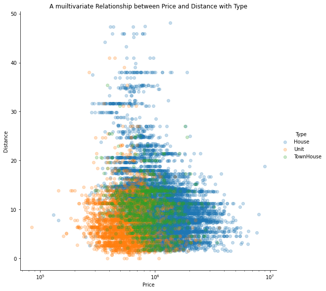

```python
pg = sb.FacetGrid(data = melb_df, hue = 'Type', height = 8)
pg.map(plt.scatter, 'Price', 'Distance',alpha=1/4)
pg.add_legend()
plt.xscale('log')
plt.title('A muiltivariate Relationship between Price and Distance with Type');
```

### Observations

> From univarite and bivariate House(cottage,villa,terrance) had dorminated in prices which is also the case here with top prices seen clearly and far streched to right which i suppose is beacuse these are sigle homed houses sitting on a single and big percel of land. Unit(duplex) also here depicts that they are price friendly with Townhouse slightly higher than units

> In terms of Distance one can clearly observe that both **Units** and **TownHouse** are closer to **Cbd** which is true since most of these structures are built for business in the industrial areas thus it hard to find alot of single houses like the case with Type **House** where they are quite distributed with some very far from CBD, at **ceteris paribus** Type house is the most dorminant across the regions

### What is interaction between Type,price and Regionname?

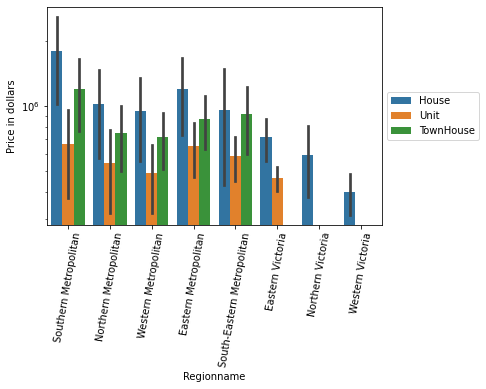

```python
# plottng
sb.barplot(data=melb_df, x='Regionname', y='Price',hue='Type',ci='sd',order=Region_order )
plt.xticks(rotation=80);
plt.yscale('log')# scaling the yaxis
plt.ylabel('Price in dollars');
plt.legend(loc = 6, bbox_to_anchor = (1.0, 0.5));
```

### Observations

> The Southern metropolitan region covers most of the wealthiest areas of Melbourne, only a few traditional Labor areas and that why all the Types of residentials are found in large numbers in the region with Type House dorminating and interestingly TownHouse second and factoring the population of Over 1 million which is quite reasonable to accommodate more residents on multi-floor buildings and this is seen across (south,west,east and north). In 2021 most people lived in separate houses (73.4%), rather than flats, apartments or other dwelling types in Victoria and that is clearly seen in our visuals where single houses are dorminant

```python
melb_df = melb_df.dropna(subset=['Car'])
```

```python
melb_df.Car.value_counts()
```

```
2     5591
1     5509
0     1026
3      748
4      506
5       63
6       54
8        9
7        8
10       3
9        1
Name: Car, dtype: int64
```

### What is interaction between Type,Carpots and Regionname?

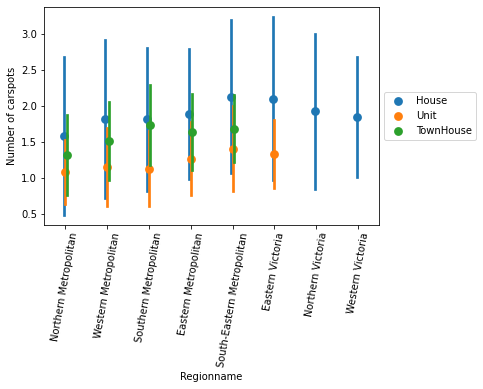

```python
sb.color_palette("rocket")
sb.pointplot(data=melb_df, x='Regionname', y='Car',hue='Type',ci='sd',dodge=True, linestyles="" )
plt.xticks(rotation=15);
plt.ylabel('Number of carspots')
plt.legend(loc = 6, bbox_to_anchor = (1.0, 0.5));
plt.xticks(rotation=80);
#linestyles=""
```

### Observations

> I have used Pointplot which represents an estimate of central tendency and one can clearly see that most residentials fall on 1 to 2 carspots with Type House dorminant with same trend of metropolitan leading in Types of buildings and also people with type house have a strong financial muscle where they can own more cars in respect with carspot

### Talk about some of the relationships you observed in this part of the investigation. Were there features that strengthened each other in terms of looking at your feature(s) of interest?

> The relationship is quite positive amomg the features where the class of a Region will definelty influnce the price, the landsize also is factor where more population with more residentials required an apartments is a good choice with distance also influencing the Type.

### Were there any interesting or surprising interactions between features?

> The relationship between Number of bathrooms and price is surprising to me in the manner that a structure with many bathrooms interpret to a big structure sitting on a big percel and should have the highest price which is not the case, arguing at (Ceteris peribus)

## Conclusions

> Data exploration is the first step in data analysis involving the use of data visualization tools and statistical techniques to uncover data set characteristics and initial patterns. After my exploration i have found that real estate is complicated investement that need a lot of variables factored in. Land is a special and prestigious commodity which has increased in value due growth in population, industrialization leading to its scarcity hence ventures in real estate. Price of the residentials vary with Types and Types buldings also factors in landsize.Many bathrooms do not results to high price but the prevalence of number of bathrooms is solely on individuals that why House type has highest number of bathrooms since they are individually owned. Prices also vary with regions depending on class of people living in those areas which is true in all places.

> My own veiw about real estate is that its capital intensive and lucrative, its population and class categorized , Location is a key and one should be mindful of negative cashflows, tenants problems and its unpredictive nature